# Brewing Logistic Regression then Going Deeper

While Caffe is made for deep networks it can likewise represent "shallow" models like logistic regression for classification. We'll do simple logistic regression on synthetic data that we'll generate and save to HDF5 to feed vectors to Caffe. Once that model is done, we'll add layers to improve accuracy. That's what Caffe is about: define a model, experiment, and then deploy.

```python
import numpy as np
import matplotlib.pyplot as plt
%matplotlib inline

import os
os.chdir('..')

import sys
sys.path.insert(0, './python')
import caffe


import os
import h5py
import shutil
import tempfile

import sklearn
import sklearn.datasets
import sklearn.linear_model

import pandas as pd

print "done"
```

```
done
```

Synthesize a dataset of 10,000 4-vectors for binary classification with 2 informative features and 2 noise features.

```
done
```

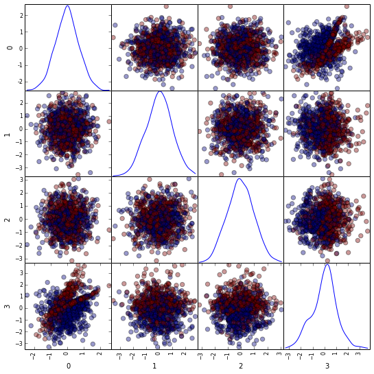

```python
X, y = sklearn.datasets.make_classification(
    n_samples=10000, n_features=4, n_redundant=0, n_informative=2,
    n_clusters_per_class=2, hypercube=False, random_state=0
)

# Split into train and test
X, Xt, y, yt = sklearn.cross_validation.train_test_split(X, y)

# Visualize sample of the data
ind = np.random.permutation(X.shape[0])[:1000]
df = pd.DataFrame(X[ind])
_ = pd.scatter_matrix(df, figsize=(9, 9), diagonal='kde', marker='o', s=40, alpha=.4, c=y[ind])
print "done"
```

Learn and evaluate scikit-learn's logistic regression with stochastic gradient descent (SGD) training. Time and check the classifier's accuracy.

```python
%%timeit
# Train and test the scikit-learn SGD logistic regression.
clf = sklearn.linear_model.SGDClassifier(
    loss='log', n_iter=1000,  penalty='l2', alpha=1e-3, class_weight='auto')
clf.fit(X, y)
yt_pred = clf.predict(Xt)
print('Accuracy: {:.3f}'.format(sklearn.metrics.accuracy_score(yt, yt_pred)))
print "done"
```

```
Accuracy: 0.770
done
```

```
Accuracy: 0.770
done
```

```
Accuracy: 0.770
done
```

```
Accuracy: 0.770
done
1 loop, best of 3: 532 ms per loop
```

在 cell-mode 里，`%%timeit` 会统计整个 cell 的运行时间。看帮助：`timeit?`

Save the dataset to HDF5 for loading in Caffe.

这个牛逼啊！scikit 和 caffe 结合一起玩！

```python
# Write out the data to HDF5 files in a temp directory.
# This file is assumed to be caffe_root/examples/hdf5_classification.ipynb
print os.path.realpath(os.getcwd())

dirname = os.path.abspath('./examples/hdf5_classification/data')
print "dirname is", dirname
if not os.path.exists(dirname):
    os.makedirs(dirname)

train_filename = os.path.join(dirname, 'train.h5')
test_filename = os.path.join(dirname, 'test.h5')

# HDF5DataLayer source should be a file containing a list of HDF5 filenames.
# To show this off, we'll list the same data file twice.
with h5py.File(train_filename, 'w') as f:
    f['data'] = X
    f['label'] = y.astype(np.float32)
with open(os.path.join(dirname, 'train.txt'), 'w') as f:
    f.write(train_filename + '\n')
    f.write(train_filename + '\n')

# HDF5 is pretty efficient, but can be further compressed.
comp_kwargs = {'compression': 'gzip', 'compression_opts': 1}
with h5py.File(test_filename, 'w') as f:
    f.create_dataset('data', data=Xt, **comp_kwargs)
    f.create_dataset('label', data=yt.astype(np.float32), **comp_kwargs)
with open(os.path.join(dirname, 'test.txt'), 'w') as f:
    f.write(test_filename + '\n')

print "done"
```

```
/home/tzx/dev/caffe-rc3
dirname is /home/tzx/dev/caffe-rc3/examples/hdf5_classification/data
done
```

```
>>> ls examples/hdf5_classification/data -alh
total 368K
drwxrwxr-x 2 tzx tzx 4.0K  6月 15 17:40 .
drwxrwxr-x 3 tzx tzx 4.0K  6月 15 17:40 ..
-rw-rw-r-- 1 tzx tzx  83K  6月 15 17:40 test.h5
-rw-rw-r-- 1 tzx tzx   66  6月 15 17:40 test.txt
-rw-rw-r-- 1 tzx tzx 266K  6月 15 17:40 train.h5
-rw-rw-r-- 1 tzx tzx  134  6月 15 17:40 train.txt
```

Let's define logistic regression in Caffe through Python net specification. This is a quick and natural way to define nets that sidesteps manually editing the protobuf model.

```python
from caffe import layers as L
from caffe import params as P

def logreg(hdf5, batch_size):
    # logistic regression: data, matrix multiplication, and 2-class softmax loss
    n = caffe.NetSpec()
    n.data, n.label = L.HDF5Data(batch_size=batch_size, source=hdf5, ntop=2)
    n.ip1 = L.InnerProduct(n.data, num_output=2, weight_filler=dict(type='xavier'))
    n.accuracy = L.Accuracy(n.ip1, n.label)
    n.loss = L.SoftmaxWithLoss(n.ip1, n.label)
    return n.to_proto()

with open('examples/hdf5_classification/logreg_auto_train.prototxt', 'w') as f:
    f.write(str(logreg('examples/hdf5_classification/data/train.txt', 10)))

with open('examples/hdf5_classification/logreg_auto_test.prototxt', 'w') as f:
    f.write(str(logreg('examples/hdf5_classification/data/test.txt', 10)))

print "done"
print "\nexamples/hdf5_classification/logreg_auto_train.prototxt"
!cat examples/hdf5_classification/logreg_auto_train.prototxt
print "\nexamples/hdf5_classification/logreg_auto_test.prototxt"
!cat examples/hdf5_classification/logreg_auto_test.prototxt
```

```
done

examples/hdf5_classification/logreg_auto_train.prototxt
layer {
  name: "data"
  type: "HDF5Data"
  top: "data"
  top: "label"
  hdf5_data_param {
    source: "examples/hdf5_classification/data/train.txt"
    batch_size: 10
  }
}
layer {
  name: "ip1"
  type: "InnerProduct"
  bottom: "data"
  top: "ip1"
  inner_product_param {
    num_output: 2
    weight_filler {
      type: "xavier"
    }
  }
}
layer {
  name: "accuracy"
  type: "Accuracy"
  bottom: "ip1"
  bottom: "label"
  top: "accuracy"
}
layer {
  name: "loss"
  type: "SoftmaxWithLoss"
  bottom: "ip1"
  bottom: "label"
  top: "loss"
}

```

[output cut: 22 more lines]

```
}
layer {
  name: "accuracy"
  type: "Accuracy"
  bottom: "ip1"
  bottom: "label"
  top: "accuracy"
}
layer {
  name: "loss"
  type: "SoftmaxWithLoss"
  bottom: "ip1"
  bottom: "label"
  top: "loss"
}
```

Time to learn and evaluate our Caffeinated logistic regression in Python.

```python
%%timeit
caffe.set_mode_cpu()
solver = caffe.get_solver('examples/hdf5_classification/solver.prototxt')
solver.solve()

accuracy = 0
batch_size = solver.test_nets[0].blobs['data'].num
test_iters = int(len(Xt) / batch_size)
for i in range(test_iters):
    solver.test_nets[0].forward()
    accuracy += solver.test_nets[0].blobs['accuracy'].data
accuracy /= test_iters

print("Accuracy: {:.3f}".format(accuracy))
```

```
Accuracy: 0.768
Accuracy: 0.768
Accuracy: 0.768
Accuracy: 0.768
The slowest run took 5.47 times longer than the fastest. This could mean that an intermediate result is being cached.
1 loop, best of 3: 136 ms per loop
```

Do the same through the command line interface for detailed output on the model and solving.

**ipython notebook 真是牛逼，随时可以运行命令行程序啊……**

```python
!./build/tools/caffe train -solver examples/hdf5_classification/solver.prototxt
print "done"
```

```
I0615 17:48:54.398427  1600 caffe.cpp:178] Use CPU.
I0615 17:48:54.787434  1600 solver.cpp:48] Initializing solver from parameters:
train_net: "examples/hdf5_classification/logreg_auto_train.prototxt"
test_net: "examples/hdf5_classification/logreg_auto_test.prototxt"
test_iter: 250
test_interval: 1000
base_lr: 0.01
display: 1000
max_iter: 10000
lr_policy: "step"
gamma: 0.1
momentum: 0.9
weight_decay: 0.0005
stepsize: 5000
snapshot: 10000
snapshot_prefix: "examples/hdf5_classification/data/train"
solver_mode: CPU
I0615 17:48:54.787585  1600 solver.cpp:81] Creating training net from train_net file: examples/hdf5_classification/logreg_auto_train.prototxt
I0615 17:48:54.787739  1600 net.cpp:49] Initializing net from parameters:
state {
  phase: TRAIN
}
layer {
  name: "data"
  type: "HDF5Data"
  top: "data"
  top: "label"
  hdf5_data_param {
    source: "examples/hdf5_classification/data/train.txt"
    batch_size: 10
  }
}
layer {
  name: "ip1"
  type: "InnerProduct"
  bottom: "data"
  top: "ip1"
  inner_product_param {
    num_output: 2
    weight_filler {
```

[output cut: 252 more lines]

```
I0615 17:48:55.047379  1600 solver.cpp:406]     Test net output #0: accuracy = 0.7724
I0615 17:48:55.047394  1600 solver.cpp:406]     Test net output #1: loss = 0.58862 (* 1 = 0.58862 loss)
I0615 17:48:55.047663  1600 solver.cpp:229] Iteration 9000, loss = 0.541651
I0615 17:48:55.047680  1600 solver.cpp:245]     Train net output #0: accuracy = 0.8
I0615 17:48:55.047689  1600 solver.cpp:245]     Train net output #1: loss = 0.541651 (* 1 = 0.541651 loss)
I0615 17:48:55.047696  1600 sgd_solver.cpp:106] Iteration 9000, lr = 0.001
I0615 17:48:55.054632  1600 solver.cpp:456] Snapshotting to binary proto file examples/hdf5_classification/data/train_iter_10000.caffemodel
I0615 17:48:55.054772  1600 sgd_solver.cpp:273] Snapshotting solver state to binary proto file examples/hdf5_classification/data/train_iter_10000.solverstate
I0615 17:48:55.054837  1600 solver.cpp:318] Iteration 10000, loss = 0.614138
I0615 17:48:55.054852  1600 solver.cpp:338] Iteration 10000, Testing net (#0)
I0615 17:48:55.056211  1600 solver.cpp:406]     Test net output #0: accuracy = 0.7684
I0615 17:48:55.056226  1600 solver.cpp:406]     Test net output #1: loss = 0.588638 (* 1 = 0.588638 loss)
I0615 17:48:55.056232  1600 solver.cpp:323] Optimization Done.
I0615 17:48:55.056238  1600 caffe.cpp:216] Optimization Done.
done
```

If you look at output or the `logreg_auto_train.prototxt`, you'll see that the model is simple logistic regression. We can make it a little more advanced by introducing a non-linearity between weights that take the input and weights that give the output -- now we have a two-layer network. That network is given in `nonlinear_auto_train.prototxt`, and that's the only change made in `nonlinear_solver.prototxt` which we will now use.

The final accuracy of the new network should be higher than logistic regression!

```python
from caffe import layers as L
from caffe import params as P

def nonlinear_net(hdf5, batch_size):
    # one small nonlinearity, one leap for model kind
    n = caffe.NetSpec()
    n.data, n.label = L.HDF5Data(batch_size=batch_size, source=hdf5, ntop=2)
    # define a hidden layer of dimension 40
    n.ip1 = L.InnerProduct(n.data, num_output=40, weight_filler=dict(type='xavier'))
    # transform the output through the ReLU (rectified linear) non-linearity
    n.relu1 = L.ReLU(n.ip1, in_place=True)
    # score the (now non-linear) features
    n.ip2 = L.InnerProduct(n.ip1, num_output=2, weight_filler=dict(type='xavier'))
    # same accuracy and loss as before
    n.accuracy = L.Accuracy(n.ip2, n.label)
    n.loss = L.SoftmaxWithLoss(n.ip2, n.label)
    return n.to_proto()

with open('examples/hdf5_classification/nonlinear_auto_train.prototxt', 'w') as f:
    f.write(str(nonlinear_net('examples/hdf5_classification/data/train.txt', 10)))

with open('examples/hdf5_classification/nonlinear_auto_test.prototxt', 'w') as f:
    f.write(str(nonlinear_net('examples/hdf5_classification/data/test.txt', 10)))

print "done"
```

```
done
```

```python
%%timeit
caffe.set_mode_cpu()
solver = caffe.get_solver('examples/hdf5_classification/nonlinear_solver.prototxt')
solver.solve()

accuracy = 0
batch_size = solver.test_nets[0].blobs['data'].num
test_iters = int(len(Xt) / batch_size)
for i in range(test_iters):
    solver.test_nets[0].forward()
    accuracy += solver.test_nets[0].blobs['accuracy'].data
accuracy /= test_iters

print("Accuracy: {:.3f}".format(accuracy))
```

```
Accuracy: 0.826
Accuracy: 0.826
Accuracy: 0.828
Accuracy: 0.824
1 loop, best of 3: 216 ms per loop
```

Do the same through the command line interface for detailed output on the model and solving.

```python
!./build/tools/caffe train -solver examples/hdf5_classification/nonlinear_solver.prototxt
```

```
I0615 17:52:52.807072  1619 caffe.cpp:178] Use CPU.
I0615 17:52:53.248281  1619 solver.cpp:48] Initializing solver from parameters:
train_net: "examples/hdf5_classification/nonlinear_auto_train.prototxt"
test_net: "examples/hdf5_classification/nonlinear_auto_test.prototxt"
test_iter: 250
test_interval: 1000
base_lr: 0.01
display: 1000
max_iter: 10000
lr_policy: "step"
gamma: 0.1
momentum: 0.9
weight_decay: 0.0005
stepsize: 5000
snapshot: 10000
snapshot_prefix: "examples/hdf5_classification/data/train"
solver_mode: CPU
I0615 17:52:53.248430  1619 solver.cpp:81] Creating training net from train_net file: examples/hdf5_classification/nonlinear_auto_train.prototxt
I0615 17:52:53.248605  1619 net.cpp:49] Initializing net from parameters:
state {
  phase: TRAIN
}
layer {
  name: "data"
  type: "HDF5Data"
  top: "data"
  top: "label"
  hdf5_data_param {
    source: "examples/hdf5_classification/data/train.txt"
    batch_size: 10
  }
}
layer {
  name: "ip1"
  type: "InnerProduct"
  bottom: "data"
  top: "ip1"
  inner_product_param {
    num_output: 40
    weight_filler {
```

[output cut: 319 more lines]

```
I0615 17:52:53.584870  1619 solver.cpp:338] Iteration 9000, Testing net (#0)
I0615 17:52:53.586987  1619 solver.cpp:406]     Test net output #0: accuracy = 0.828
I0615 17:52:53.587004  1619 solver.cpp:406]     Test net output #1: loss = 0.391263 (* 1 = 0.391263 loss)
I0615 17:52:53.587291  1619 solver.cpp:229] Iteration 9000, loss = 0.376525
I0615 17:52:53.587308  1619 solver.cpp:245]     Train net output #0: accuracy = 0.9
I0615 17:52:53.587317  1619 solver.cpp:245]     Train net output #1: loss = 0.376526 (* 1 = 0.376526 loss)
I0615 17:52:53.587326  1619 sgd_solver.cpp:106] Iteration 9000, lr = 0.001
I0615 17:52:53.600651  1619 solver.cpp:456] Snapshotting to binary proto file examples/hdf5_classification/data/train_iter_10000.caffemodel
I0615 17:52:53.600813  1619 sgd_solver.cpp:273] Snapshotting solver state to binary proto file examples/hdf5_classification/data/train_iter_10000.solverstate
I0615 17:52:53.600880  1619 solver.cpp:318] Iteration 10000, loss = 0.26334
I0615 17:52:53.600894  1619 solver.cpp:338] Iteration 10000, Testing net (#0)
I0615 17:52:53.602987  1619 solver.cpp:406]     Test net output #0: accuracy = 0.8252
I0615 17:52:53.603000  1619 solver.cpp:406]     Test net output #1: loss = 0.393304 (* 1 = 0.393304 loss)
I0615 17:52:53.603008  1619 solver.cpp:323] Optimization Done.
I0615 17:52:53.603011  1619 caffe.cpp:216] Optimization Done.
```

```python
# Clean up (comment this out if you want to examine the hdf5_classification/data directory).
# shutil.rmtree(dirname)
```